# Metro Interstate Traffic Volumen

Simon Gamboa

2022-07-04

# GOAL

We will be analyzing how changes in the climate can affect the traffic volume for westbound interstate I-94 from 2012-2018. Then we carry out a multilinear regression model to predict how temperature, raining and snow could impact the traffic volume.

# Data set information

We selected the metro interstate traffic volume data set from the UCI Machine Learning Repository (2022). The data was captured from hourly Interstate 94 Westbound traffic volume for MN DoT ATR station 301, roughly midway between Minneapolis and St Paul, MN. Hourly weather features and holidays included for impacts on traffic volume.The data set belong to Traffic data from Minnesota Department of Transportation - USA.

#STEP 1: READ AND PROCESS THE DATA ##1.1 Read the data

```r
df <- read.csv("Metro_Interstate_Traffic_Volume.csv", header=TRUE, sep=",")
head(df, 3)
```

```
##   holiday   temp rain_1h snow_1h clouds_all weather_main weather_description
## 1    None 288.28       0       0         40       Clouds    scattered clouds
## 2    None 289.36       0       0         75       Clouds       broken clouds
## 3    None 289.58       0       0         90       Clouds     overcast clouds
##             date_time traffic_volume
## 1 2012-10-02 09:00:00           5545
## 2 2012-10-02 10:00:00           4516
## 3 2012-10-02 11:00:00           4767
```

##1.2 Process the data ###1.2.1 check unique value

```r
unique(df$holiday)
```

```
##  [1] "None"                      "Columbus Day"
##  [3] "Veterans Day"              "Thanksgiving Day"
##  [5] "Christmas Day"             "New Years Day"
##  [7] "Washingtons Birthday"      "Memorial Day"
##  [9] "Independence Day"          "State Fair"
## [11] "Labor Day"                 "Martin Luther King Jr Day"
```

```r
unique(df$weather_main)
```

```
##  [1] "Clouds"       "Clear"        "Rain"         "Drizzle"      "Mist"
##  [6] "Haze"         "Fog"          "Thunderstorm" "Snow"         "Squall"
## [11] "Smoke"
```

###1.2.2 check null and blank value, drop row that contain null or blank value

```r
sum(is.na(df))
```

```
## [1] 0
```

```r
sum(df=="")
```

```
## [1] 0
```

###1.2.3 split date and time column variable

```r
df$time <- as.integer(format(as.POSIXct(df$date_time), format = "%H"))
head(df)
```

```
##   holiday   temp rain_1h snow_1h clouds_all weather_main weather_description
## 1    None 288.28       0       0         40       Clouds    scattered clouds
## 2    None 289.36       0       0         75       Clouds       broken clouds
## 3    None 289.58       0       0         90       Clouds     overcast clouds
## 4    None 290.13       0       0         90       Clouds     overcast clouds
## 5    None 291.14       0       0         75       Clouds       broken clouds
## 6    None 291.72       0       0          1        Clear        sky is clear
##             date_time traffic_volume time
## 1 2012-10-02 09:00:00           5545    9
## 2 2012-10-02 10:00:00           4516   10
## 3 2012-10-02 11:00:00           4767   11
## 4 2012-10-02 12:00:00           5026   12
## 5 2012-10-02 13:00:00           4918   13
## 6 2012-10-02 14:00:00           5181   14
```

###1.2.3 drop unneeded columns and rows

```r
df <- df[,-c(7,8)]
head(df)
```

```
##   holiday   temp rain_1h snow_1h clouds_all weather_main traffic_volume time
## 1    None 288.28       0       0         40       Clouds           5545    9
## 2    None 289.36       0       0         75       Clouds           4516   10
## 3    None 289.58       0       0         90       Clouds           4767   11
## 4    None 290.13       0       0         90       Clouds           5026   12
## 5    None 291.14       0       0         75       Clouds           4918   13
## 6    None 291.72       0       0          1        Clear           5181   14
```

```r
#There were deleted temperature values as 0 because is outside kelvin range
library(dplyr)
df <- df %>% filter(temp >= 243)
```

#STEP 2: TRANSFORMING DATA SET ##2.1 check categories variable frequency ##load & required package

```r
#install.packages("dplyr")
library(dplyr)
#install.packages("funModeling")
library(funModeling)
```

## 2.2 First approaching of exploation data analytics (EDA)

```
## Rows: 48,194
## Columns: 8
## $ holiday        <chr> "None", "None", "None", "None", "None", "None", "None",…
## $ temp           <dbl> 288.28, 289.36, 289.58, 290.13, 291.14, 291.72, 293.17,…
## $ rain_1h        <dbl> 0, 0, 0, 0, 0, 0, 0, 0, 0, 0, 0, 0, 0, 0, 0, 0, 0, 0, 0…
## $ snow_1h        <dbl> 0, 0, 0, 0, 0, 0, 0, 0, 0, 0, 0, 0, 0, 0, 0, 0, 0, 0, 0…
## $ clouds_all     <int> 40, 75, 90, 90, 75, 1, 1, 1, 20, 20, 20, 1, 1, 1, 1, 1,…
## $ weather_main   <chr> "Clouds", "Clouds", "Clouds", "Clouds", "Clouds", "Clea…
## $ traffic_volume <int> 5545, 4516, 4767, 5026, 4918, 5181, 5584, 6015, 5791, 4…
## $ time           <int> 9, 10, 11, 12, 13, 14, 15, 16, 17, 18, 19, 20, 21, 22, …
##                      variable q_zeros      p_zeros q_na p_na q_inf p_inf
## holiday               holiday       0 0.000000e+00    0    0     0     0
## temp                     temp       0 0.000000e+00    0    0     0     0
## rain_1h               rain_1h   44727 9.280616e-01    0    0     0     0
## snow_1h               snow_1h   48131 9.986928e-01    0    0     0     0
## clouds_all         clouds_all    1978 4.104245e-02    0    0     0     0
## weather_main     weather_main       0 0.000000e+00    0    0     0     0
## traffic_volume traffic_volume       2 4.149894e-05    0    0     0     0
## time                     time    2037 4.226667e-02    0    0     0     0
##                     type unique
## holiday        character     12
## temp             numeric   5842
## rain_1h          numeric    372
## snow_1h          numeric     12
## clouds_all       integer     60
## weather_main   character     11
## traffic_volume   integer   6704
## time             integer     24
```

```
##                      holiday frequency percentage cumulative_perc
## 1                       None     48133      99.87           99.87
## 2                  Labor Day         7       0.01           99.88
## 3              Christmas Day         6       0.01           99.89
## 4  Martin Luther King Jr Day         6       0.01           99.90
## 5              New Years Day         6       0.01           99.91
## 6           Thanksgiving Day         6       0.01           99.92
## 7               Columbus Day         5       0.01           99.93
## 8           Independence Day         5       0.01           99.94
## 9               Memorial Day         5       0.01           99.95
## 10                State Fair         5       0.01           99.96
## 11              Veterans Day         5       0.01           99.97
## 12      Washingtons Birthday         5       0.01          100.00
```

```
##    weather_main frequency percentage cumulative_perc
## 1        Clouds     15164      31.46           31.46
## 2         Clear     13381      27.76           59.22
## 3          Mist      5950      12.35           71.57
## 4          Rain      5672      11.77           83.34
## 5          Snow      2876       5.97           89.31
## 6       Drizzle      1821       3.78           93.09
## 7          Haze      1360       2.82           95.91
## 8  Thunderstorm      1034       2.15           98.06
## 9           Fog       912       1.89           99.95
## 10        Smoke        20       0.04           99.99
## 11       Squall         4       0.01          100.00
##
##         variable         mean      std_dev variation_coef     p_01   p_05
## 1           temp 2.812642e+02 1.270959e+01     0.04518736 250.8393 258.36
```

[output cut: 19 more lines]

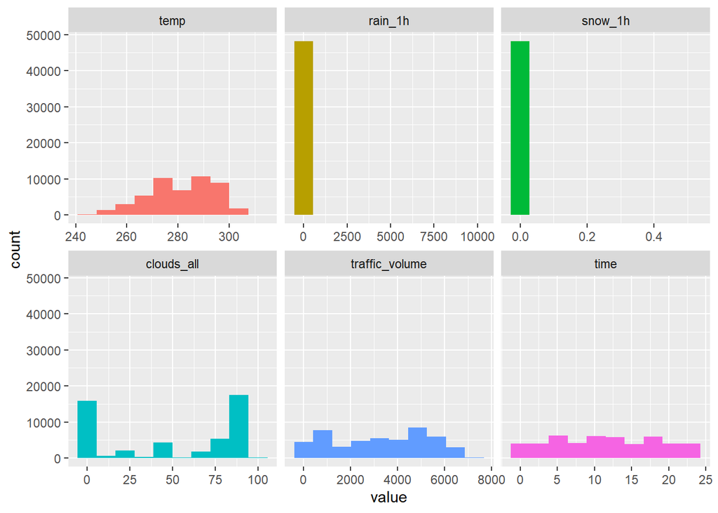

```
## df
##
##  8  Variables      48194  Observations
## --------------------------------------------------------------------------------
## holiday
##        n  missing distinct
##    48194        0       12
##
## lowest : Christmas Day             Columbus Day              Independence Day          Labor Day                 Martin Luther King Jr Day
## highest: None                      State Fair                Thanksgiving Day          Veterans Day              Washingtons Birthday
## --------------------------------------------------------------------------------
## temp
##        n  missing distinct     Info     Mean      Gmd      .05      .10
##    48194        0     5842        1    281.3    14.49    258.4    264.0
##      .25      .50      .75      .90      .95
##    272.2    282.5    291.8    296.7    299.3
##
## lowest : 243.39 243.62 244.22 244.82 244.89, highest: 308.87 308.95 309.08 309.29 310.07
## --------------------------------------------------------------------------------
## rain_1h
##        n  missing distinct     Info     Mean      Gmd      .05      .10
##    48194        0      372    0.201   0.3343    0.662      0.0      0.0
##      .25      .50      .75      .90      .95
##      0.0      0.0      0.0      0.0      0.3
##
## lowest :    0.00    0.25    0.26    0.27    0.28
## highest:   28.70   31.75   44.45   55.63 9831.30
##
## Value          0   100  9800
## Frequency  48192     1     1
## Proportion     1     0     0
##
## For the frequency table, variable is rounded to the nearest 100
## --------------------------------------------------------------------------------
## snow_1h
##         n   missing  distinct      Info      Mean       Gmd       .05       .10
##     48194         0        12     0.004 0.0002224 0.0004446         0         0
##       .25       .50       .75       .90       .95
##         0         0         0         0         0
##
```

[output cut: 30 more lines]

```
##        n  missing distinct     Info     Mean      Gmd      .05      .10
##    48194        0     6704        1     3260     2282      339      425
##      .25      .50      .75      .90      .95
##     1194     3380     4933     5820     6197
##
## lowest :    0    1    2    3    5, highest: 7213 7217 7241 7260 7280
## --------------------------------------------------------------------------------
## time
##        n  missing distinct     Info     Mean      Gmd      .05      .10
##    48194        0       24    0.998     11.4    8.007        1        2
##      .25      .50      .75      .90      .95
##        5       11       17       21       22
##
## lowest :  0  1  2  3  4, highest: 19 20 21 22 23
## --------------------------------------------------------------------------------
```

```r
basic_eda <- function(df)
{
  glimpse(df)
  print(status(df))
  freq(df, path_out = ".")
  print(profiling_num(df))
  plot_num(df)
  describe(df)
}
basic_eda(df)
```

```r
## check frequency

count(df, weather_main)
```

```
##    weather_main     n
## 1         Clear 13381
## 2        Clouds 15164
## 3       Drizzle  1821
## 4           Fog   912
## 5          Haze  1360
## 6          Mist  5950
## 7          Rain  5672
## 8         Smoke    20
## 9          Snow  2876
## 10       Squall     4
## 11 Thunderstorm  1034
```

```r
count(df, holiday)
```

```
##                      holiday     n
## 1              Christmas Day     6
## 2               Columbus Day     5
## 3           Independence Day     5
## 4                  Labor Day     7
## 5  Martin Luther King Jr Day     6
## 6               Memorial Day     5
## 7              New Years Day     6
## 8                       None 48133
## 9                 State Fair     5
## 10          Thanksgiving Day     6
## 11              Veterans Day     5
## 12      Washingtons Birthday     5
```

```r
count(df, time)
```

```
##    time    n
## 1     0 2037
## 2     1 2049
## 3     2 2019
## 4     3 2023
## 5     4 2089
## 6     5 2061
## 7     6 2085
## 8     7 2078
## 9     8 2079
## 10    9 2018
## 11   10 2078
## 12   11 1952
## 13   12 1955
## 14   13 1905
## 15   14 1969
## 16   15 1934
## 17   16 1988
## 18   17 1933
## 19   18 1986
## 20   19 1961
## 21   20 1979
## 22   21 1982
## 23   22 1994
## 24   23 2040
```

```r
count(df, temp)
```

[output not shown]

[output cut: 5828 more lines]

##2.2 combine various holiday into holiday value

```r
df <- df %>% mutate(holiday = case_when(holiday == "None"   ~ "No",
                                            TRUE  ~  "Yes"))

head(df)
```

```
##   holiday   temp rain_1h snow_1h clouds_all weather_main traffic_volume time
## 1      No 288.28       0       0         40       Clouds           5545    9
## 2      No 289.36       0       0         75       Clouds           4516   10
## 3      No 289.58       0       0         90       Clouds           4767   11
## 4      No 290.13       0       0         90       Clouds           5026   12
## 5      No 291.14       0       0         75       Clouds           4918   13
## 6      No 291.72       0       0          1        Clear           5181   14
```

###2.3 group various weather value ##==================================== ## good weather - Clear ## moderately good weather - Clouds ## moderately bad weather - Fog, Haze, Smoke, Mist, Drizzle ## bad weather - Thunderstorm, Squall, Rain, snow

```r
df <- df %>% mutate(weather_main = case_when(weather_main == "Thunderstorm"  | weather_main == "Squall" | weather_main == "Rain" | weather_main == "Snow"  ~
                                               "bad weather", weather_main == "Fog" |
                                               weather_main == "Haze" |
                                               weather_main == "Smoke" |
                                               weather_main == "Mist" |
                                               weather_main == "Drizzle" ~ "moderately bad weather",
                                             weather_main == "Clouds"  ~ "moderately good weather",
                                             weather_main == "Clear"  ~ "good weather"
                                             )
                    )
head(df)
```

```
##   holiday   temp rain_1h snow_1h clouds_all            weather_main
## 1      No 288.28       0       0         40 moderately good weather
## 2      No 289.36       0       0         75 moderately good weather
## 3      No 289.58       0       0         90 moderately good weather
## 4      No 290.13       0       0         90 moderately good weather
## 5      No 291.14       0       0         75 moderately good weather
## 6      No 291.72       0       0          1            good weather
##   traffic_volume time
## 1           5545    9
## 2           4516   10
## 3           4767   11
## 4           5026   12
## 5           4918   13
## 6           5181   14
```

#STEP 3: EXPLORE THE DATA ##PLOTS ## weather vs. traffic volume ## holiday vs. traffic volume ## time vs. traffic volume

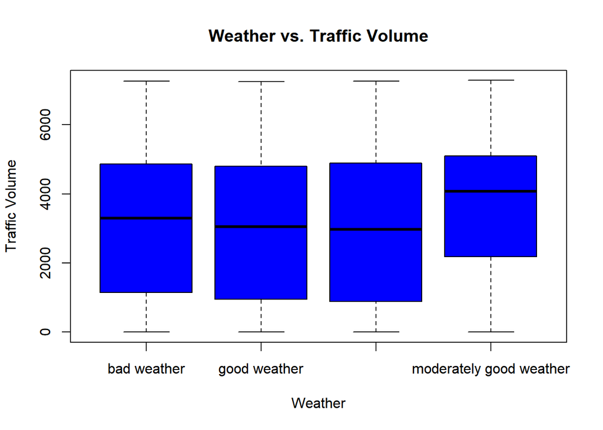

```r
#weather vs. traffic volume
df$weather_main <- factor(df$weather)

plot(df$weather_main, df$traffic_volume, main="Weather vs. Traffic Volume", xlab = "Weather", ylab="Traffic Volume", pch="*", col="blue", cex=2)
```

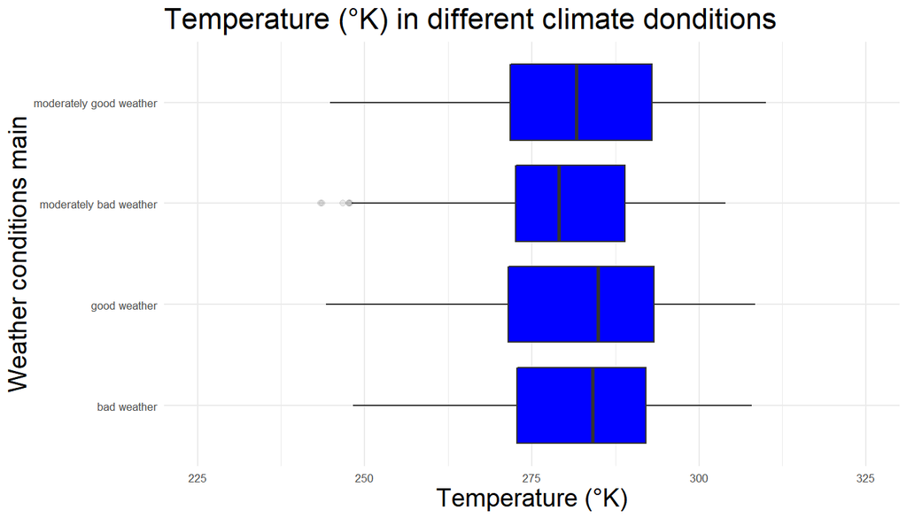

```r
# Weather conditions vs temperature
p <- ggplot(df, aes(x=temp, y=weather_main)) +
  geom_boxplot(outlier.alpha = 0.1, fill='blue') +
  theme_minimal(base_size = 8) + xlim(225, 325) +
  labs(title = "Temperature (°K) in different climate donditions",
       x = "Temperature (°K)", y = "Weather conditions main") +
  theme(plot.title = element_text(size=16),
        axis.title.x = element_text(size=14),
        axis.title.y = element_text(size=14))
p
```

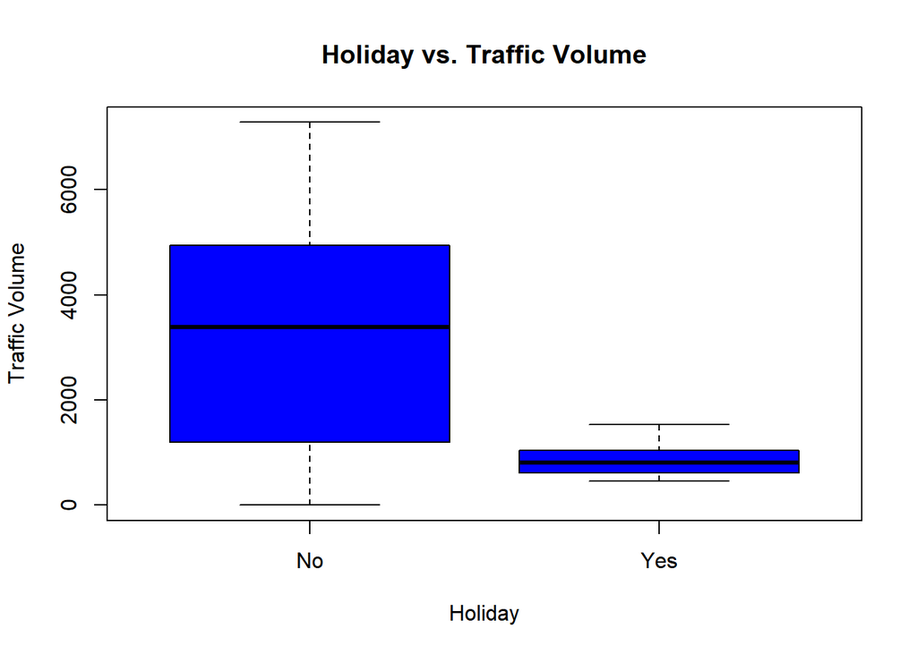

```r
#holiday vs. traffic volume
df$holiday <- factor(df$holiday)

plot(df$holiday, df$traffic_volume, main="Holiday vs. Traffic Volume", xlab = "Holiday", ylab="Traffic Volume", pch="*", col="blue", cex=0.5)
```

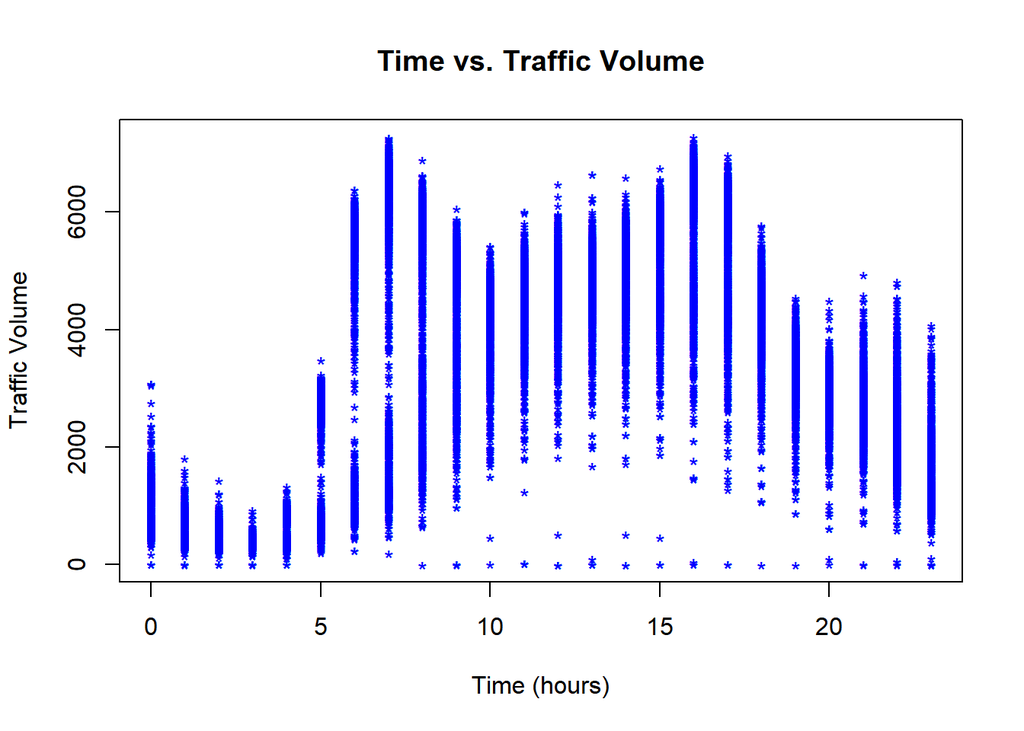

```r
## time vs. traffic volume
plot(df$time, df$traffic_volume, main="Time vs. Traffic Volume", xlab = "Time (hours)", ylab="Traffic Volume", pch="*", col="blue", cex=1)
```

#STEP 4: CONVERTING CATEGORICAL VARIABLES TO DUMMY VARIABLES

##4.1 subset for holiday and weather

```r
cat_data <- subset(df, select=c(holiday, weather_main))
head(cat_data)
```

```
##   holiday            weather_main
## 1      No moderately good weather
## 2      No moderately good weather
## 3      No moderately good weather
## 4      No moderately good weather
## 5      No moderately good weather
## 6      No            good weather
```

##4.2 get dummy variables in R, use the model.matrix() function

```r
holiday_Dumm <- model.matrix(~holiday, data=cat_data)
weather_main_Dumm <- model.matrix(~weather_main, data=cat_data)
head(holiday_Dumm)
```

```
##   (Intercept) holidayYes
## 1           1          0
## 2           1          0
## 3           1          0
## 4           1          0
## 5           1          0
## 6           1          0
```

```r
head(weather_main_Dumm)
```

```
##   (Intercept) weather_maingood weather weather_mainmoderately bad weather
## 1           1                        0                                  0
## 2           1                        0                                  0
## 3           1                        0                                  0
## 4           1                        0                                  0
## 5           1                        0                                  0
## 6           1                        1                                  0
##   weather_mainmoderately good weather
## 1                                   1
## 2                                   1
## 3                                   1
## 4                                   1
## 5                                   1
## 6                                   0
```

##4.3 bind the dummies to the original data

```r
holiday <- holiday_Dumm[,c(2)]
good_weather <- weather_main_Dumm[,c(2)]
moderately_bad_weather <- weather_main_Dumm[,c(3)]
moderately_good_weather <- weather_main_Dumm[,c(4)]
df1 <- df[,-c(1,6)]

df2 <- cbind(df1,holiday,moderately_bad_weather,moderately_good_weather,good_weather)

head(df2)
```

```
##     temp rain_1h snow_1h clouds_all traffic_volume time holiday
## 1 288.28       0       0         40           5545    9       0
## 2 289.36       0       0         75           4516   10       0
## 3 289.58       0       0         90           4767   11       0
## 4 290.13       0       0         90           5026   12       0
## 5 291.14       0       0         75           4918   13       0
## 6 291.72       0       0          1           5181   14       0
##   moderately_bad_weather moderately_good_weather good_weather
## 1                      0                       1            0
## 2                      0                       1            0
## 3                      0                       1            0
## 4                      0                       1            0
## 5                      0                       1            0
## 6                      0                       0            1
```

#SAVING CLEANED DATA SET

```r
write.csv(df2, "final_df.csv")
```

# GOAL: We will be analysing how traffic volume is affected by weather conditions

# STEP 3 MULTILINEAR REGRESSION MODEL

## 3.1 Reading data set cleaned

```r
metro_df <- read.csv("final_df.csv", header = TRUE, sep = ",")
str(metro_df)
```

```
## 'data.frame':    48194 obs. of  11 variables:
##  $ X                      : int  1 2 3 4 5 6 7 8 9 10 ...
##  $ temp                   : num  288 289 290 290 291 ...
##  $ rain_1h                : num  0 0 0 0 0 0 0 0 0 0 ...
##  $ snow_1h                : num  0 0 0 0 0 0 0 0 0 0 ...
##  $ clouds_all             : int  40 75 90 90 75 1 1 1 20 20 ...
##  $ traffic_volume         : int  5545 4516 4767 5026 4918 5181 5584 6015 5791 4770 ...
##  $ time                   : int  9 10 11 12 13 14 15 16 17 18 ...
##  $ holiday                : int  0 0 0 0 0 0 0 0 0 0 ...
##  $ moderately_bad_weather : int  0 0 0 0 0 0 0 0 0 0 ...
##  $ moderately_good_weather: int  1 1 1 1 1 0 0 0 1 1 ...
##  $ good_weather           : int  0 0 0 0 0 1 1 1 0 0 ...
```

# STEP 4: FORMATTING AND REMOVING COLUMNS

```r
#Removing unnecessary column
metro_df <- metro_df[,-c(1)]
str(metro_df)
```

```
## 'data.frame':    48194 obs. of  10 variables:
##  $ temp                   : num  288 289 290 290 291 ...
##  $ rain_1h                : num  0 0 0 0 0 0 0 0 0 0 ...
##  $ snow_1h                : num  0 0 0 0 0 0 0 0 0 0 ...
##  $ clouds_all             : int  40 75 90 90 75 1 1 1 20 20 ...
##  $ traffic_volume         : int  5545 4516 4767 5026 4918 5181 5584 6015 5791 4770 ...
##  $ time                   : int  9 10 11 12 13 14 15 16 17 18 ...
##  $ holiday                : int  0 0 0 0 0 0 0 0 0 0 ...
##  $ moderately_bad_weather : int  0 0 0 0 0 0 0 0 0 0 ...
##  $ moderately_good_weather: int  1 1 1 1 1 0 0 0 1 1 ...
##  $ good_weather           : int  0 0 0 0 0 1 1 1 0 0 ...
```

# STEP 5: SELECTING NUMERIC VARIABLE TO LOG TRANSFORMATION

```r
metro_df <- metro_df %>% dplyr::select(where(is.numeric))
str(metro_df)
```

```
## 'data.frame':    48194 obs. of  10 variables:
##  $ temp                   : num  288 289 290 290 291 ...
##  $ rain_1h                : num  0 0 0 0 0 0 0 0 0 0 ...
##  $ snow_1h                : num  0 0 0 0 0 0 0 0 0 0 ...
##  $ clouds_all             : int  40 75 90 90 75 1 1 1 20 20 ...
##  $ traffic_volume         : int  5545 4516 4767 5026 4918 5181 5584 6015 5791 4770 ...
##  $ time                   : int  9 10 11 12 13 14 15 16 17 18 ...
##  $ holiday                : int  0 0 0 0 0 0 0 0 0 0 ...
##  $ moderately_bad_weather : int  0 0 0 0 0 0 0 0 0 0 ...
##  $ moderately_good_weather: int  1 1 1 1 1 0 0 0 1 1 ...
##  $ good_weather           : int  0 0 0 0 0 1 1 1 0 0 ...
```

# STEP 6: ASSESSING THE EXPLANATORY MODEL

## 6.1. We modelling the relationship between Traffic volume and weather conditions throug out different day and time moments

```r
full_model_1 <- lm(traffic_volume~., data = metro_df)
options(scipen = 999)
summary(full_model_1)
```

```
##
## Call:
## lm(formula = traffic_volume ~ ., data = metro_df)
##
## Residuals:
##     Min      1Q  Median      3Q     Max
## -4771.6 -1660.1   -67.1  1549.9  4796.5
##
## Coefficients:
##                           Estimate Std. Error t value             Pr(>|t|)
## (Intercept)             -2438.2239   195.3208 -12.483 < 0.0000000000000002 ***
## temp                       15.5269     0.6739  23.039 < 0.0000000000000002 ***
## rain_1h                     0.1295     0.1872   0.692               0.4890
## snow_1h                   -38.4453  1027.2239  -0.037               0.9701
## clouds_all                  2.3650     0.3399   6.959     0.00000000000348 ***
## time                       94.3772     1.2323  76.586 < 0.0000000000000002 ***
## holiday                 -1256.1646   236.1741  -5.319     0.00000010491480 ***
## moderately_bad_weather     50.3790    26.5067   1.901               0.0574 .
## moderately_good_weather   359.6995    24.3598  14.766 < 0.0000000000000002 ***
## good_weather               59.5062    35.0218   1.699               0.0893 .
## ---
## Signif. codes:  0 '***' 0.001 '**' 0.01 '*' 0.05 '.' 0.1 ' ' 1
##
## Residual standard error: 1840 on 48184 degrees of freedom
## Multiple R-squared:  0.1422, Adjusted R-squared:  0.1421
## F-statistic: 887.8 on 9 and 48184 DF,  p-value: < 0.00000000000000022
```

## 6.2. Finding outliers, selecting and deleting outliers

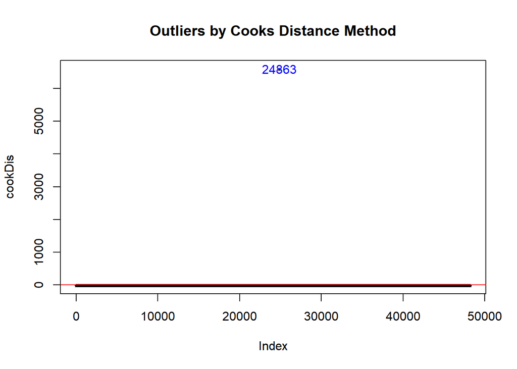

```r
cookDis <- cooks.distance(full_model_1)
plot(cookDis, pch='*', cex=0.8, main='Outliers by Cooks Distance Method')
abline(h=4*mean(cookDis, na.rm=TRUE), col='red')
text(x=1:length(cookDis)+1, y=cookDis, labels = ifelse(cookDis>4*mean(cookDis, na.rm = TRUE), names(cookDis),""), col = "blue")
```

## 6.3. Selecting and Deleting outliers

```r
outliers_rows <- cookDis>4*mean(cookDis)

df_outliers <- cbind(metro_df, outliers_rows)
nrow(df_outliers)
```

```
## [1] 48194
```

```r
nrow(df_outliers[(df_outliers$outliers_rows=='FALSE'),])
```

```
## [1] 48193
```

```r
nrow(df_outliers[(df_outliers$outliers_rows=='TRUE'),])
```

```
## [1] 1
```

```r
#deleting outliers
df_outliers <- df_outliers[(df_outliers$outliers_rows=='FALSE'), ]
df_outliers <- subset(df_outliers, select = -c(outliers_rows))
```

## STEP 7: TESTING THE EXPLANATORY MODEL FROM ORIGINAL DATA SET WITHOUT OUTLIERS

```r
#Model 1 Original data set

model_1_full <- lm(traffic_volume~., data = df_outliers)
options(scipen = 999)
summary(model_1_full)
```

```
##
## Call:
## lm(formula = traffic_volume ~ ., data = df_outliers)
##
## Residuals:
##     Min      1Q  Median      3Q     Max
## -4776.5 -1659.1   -66.5  1551.2  4807.0
##
## Coefficients:
##                           Estimate Std. Error t value             Pr(>|t|)
## (Intercept)             -2520.1526   195.7988 -12.871 < 0.0000000000000002 ***
## temp                       15.8888     0.6768  23.478 < 0.0000000000000002 ***
## rain_1h                   -47.9225     8.5280  -5.619     0.00000001926495 ***
## snow_1h                   -52.4373  1026.8992  -0.051                0.959
## clouds_all                  2.4101     0.3399   7.091     0.00000000000135 ***
## time                       94.2640     1.2321  76.508 < 0.0000000000000002 ***
## holiday                 -1258.9192   236.0993  -5.332     0.00000009748738 ***
## moderately_bad_weather     38.0739    26.5880   1.432                0.152
## moderately_good_weather   338.2981    24.6463  13.726 < 0.0000000000000002 ***
## good_weather               40.6967    35.1693   1.157                0.247
## ---
## Signif. codes:  0 '***' 0.001 '**' 0.01 '*' 0.05 '.' 0.1 ' ' 1
##
## Residual standard error: 1840 on 48183 degrees of freedom
## Multiple R-squared:  0.1428, Adjusted R-squared:  0.1426
## F-statistic: 891.7 on 9 and 48183 DF,  p-value: < 0.00000000000000022
```

# STEP 8: IMPROVING THE EXPLANATORY MODEL WITH STEPWISE REGRESSION MODEL

```r
library(MASS)
#Model 2 Reducing the original model with Stepwise regression model

model_2_step <- stepAIC(full_model_1, direction = "backward", trace = FALSE)
summary(model_2_step)
```

```
##
## Call:
## lm(formula = traffic_volume ~ temp + clouds_all + time + holiday +
##     moderately_bad_weather + moderately_good_weather + good_weather,
##     data = metro_df)
##
## Residuals:
##     Min      1Q  Median      3Q     Max
## -4771.7 -1660.1   -67.1  1550.0  4796.7
##
## Coefficients:
##                           Estimate Std. Error t value             Pr(>|t|)
## (Intercept)             -2439.4047   195.2785 -12.492 < 0.0000000000000002 ***
## temp                       15.5316     0.6738  23.052 < 0.0000000000000002 ***
## clouds_all                  2.3652     0.3398   6.960     0.00000000000345 ***
## time                       94.3787     1.2322  76.595 < 0.0000000000000002 ***
## holiday                 -1256.1544   236.1704  -5.319     0.00000010489119 ***
## moderately_bad_weather     50.2281    26.5052   1.895               0.0581 .
## moderately_good_weather   359.5321    24.3508  14.765 < 0.0000000000000002 ***
## good_weather               59.3480    35.0197   1.695               0.0901 .
## ---
## Signif. codes:  0 '***' 0.001 '**' 0.01 '*' 0.05 '.' 0.1 ' ' 1
##
## Residual standard error: 1840 on 48186 degrees of freedom
## Multiple R-squared:  0.1422, Adjusted R-squared:  0.1421
## F-statistic:  1141 on 7 and 48186 DF,  p-value: < 0.00000000000000022
```

## STEP 9: EVALUATION OF MODELS BASED ON Akaike Information Criteria (AIC) ANALYSIS AND R-SQUARED SCORE

```r
# Evaluations model from original data set without outliers

full_model_AIC <- AIC(model_1_full)
step_model_AIC <- AIC(model_2_step)

print(paste0("Full model     AIC score: ", full_model_AIC))
```

```
## [1] "Full model     AIC score: 861342.145002938"
```

```r
print(paste0("Full mode      R-squared: ", summary(model_1_full)$r.squared))
```

```
## [1] "Full mode      R-squared: 0.142782046683378"
```

```r
print(paste0(""))
```

```
## [1] ""
```

```r
print(paste0("Stepwise model AIC score: ", step_model_AIC))
```

```
## [1] "Stepwise model AIC score: 861387.258464806"
```

```r
print(paste0("Stepwise model R-squared: ", summary(model_2_step)$r.squared))
```

```
## [1] "Stepwise model R-squared: 0.142231721337549"
```

# STEP 10: LOG TRANSFORMATION OF ORIGINAL DATA SET

```r
# Log transformation of numeric variables from original data set without outliers

metro_Log <- df_outliers

metro_Log[c("temp", "rain_1h", "snow_1h", "clouds_all", "traffic_volume", "time")] <- log1p(metro_Log[c("temp", "rain_1h", "snow_1h", "clouds_all", "traffic_volume", "time")])
```

# STEP 11: RUNNING MODELS LOG TRANSFORMATED

## 10.1 Full model Log transformated

```r
# Model 3 Log transformation

model_3_full_log <- lm(traffic_volume~., data = metro_Log)
summary(model_3_full_log)
```

```
##
## Call:
## lm(formula = traffic_volume ~ ., data = metro_Log)
##
## Residuals:
##     Min      1Q  Median      3Q     Max
## -8.5333 -0.5170  0.1879  0.5220  2.0013
##
## Coefficients:
##                          Estimate Std. Error t value             Pr(>|t|)
## (Intercept)             -1.458158   0.432113  -3.374             0.000740 ***
## temp                     1.305214   0.076339  17.098 < 0.0000000000000002 ***
## rain_1h                 -0.089149   0.013757  -6.480    0.000000000092364 ***
## snow_1h                 -0.199387   0.488536  -0.408             0.683178
## clouds_all               0.027149   0.003755   7.230    0.000000000000488 ***
## time                     0.758618   0.004245 178.719 < 0.0000000000000002 ***
## holiday                  0.697618   0.095462   7.308    0.000000000000276 ***
## moderately_bad_weather   0.026928   0.010804   2.492             0.012694 *
## moderately_good_weather  0.086437   0.010033   8.616 < 0.0000000000000002 ***
## good_weather             0.060365   0.016136   3.741             0.000183 ***
## ---
## Signif. codes:  0 '***' 0.001 '**' 0.01 '*' 0.05 '.' 0.1 ' ' 1
##
## Residual standard error: 0.7414 on 48183 degrees of freedom
## Multiple R-squared:  0.4231, Adjusted R-squared:  0.423
## F-statistic:  3927 on 9 and 48183 DF,  p-value: < 0.00000000000000022
```

## 11.2 Stepwise model of Full model Log transformated

```r
# Model 4 reducing model 3 Stepwise model (Log) with stepwise regression

model_4_step_log <- stepAIC(model_3_full_log, direction = "backward", trace = FALSE)
options(scipen = 999)
summary(model_4_step_log)
```

```
##
## Call:
## lm(formula = traffic_volume ~ temp + rain_1h + clouds_all + time +
##     holiday + moderately_bad_weather + moderately_good_weather +
##     good_weather, data = metro_Log)
##
## Residuals:
##     Min      1Q  Median      3Q     Max
## -8.5332 -0.5170  0.1879  0.5220  2.0014
##
## Coefficients:
##                          Estimate Std. Error t value             Pr(>|t|)
## (Intercept)             -1.461482   0.432032  -3.383             0.000718 ***
## temp                     1.305807   0.076325  17.109 < 0.0000000000000002 ***
## rain_1h                 -0.089150   0.013757  -6.480    0.000000000092308 ***
## clouds_all               0.027126   0.003754   7.225    0.000000000000508 ***
## time                     0.758602   0.004245 178.724 < 0.0000000000000002 ***
## holiday                  0.697621   0.095461   7.308    0.000000000000276 ***
## moderately_bad_weather   0.026942   0.010804   2.494             0.012644 *
## moderately_good_weather  0.086547   0.010029   8.630 < 0.0000000000000002 ***
## good_weather             0.060394   0.016136   3.743             0.000182 ***
## ---
## Signif. codes:  0 '***' 0.001 '**' 0.01 '*' 0.05 '.' 0.1 ' ' 1
##
## Residual standard error: 0.7414 on 48184 degrees of freedom
## Multiple R-squared:  0.4231, Adjusted R-squared:  0.423
## F-statistic:  4417 on 8 and 48184 DF,  p-value: < 0.00000000000000022
```